# 第9回 データを分析する（2）：カテゴリデータの分析（カイ二乗検定）

行動計量学（行動科学分析法入門）

小野原 彩香

令和8年度

## 本日の目標

1. カテゴリデータの分析が必要な場面を理解する
2. クロス集計表（分割表）を作成できる
3. カイ二乗検定（独立性の検定）をRで実行し，結果を解釈できる
4. 検定が使える条件を確認し，使えないときの代わりを知る
5. **発展**：期待度数・カイ二乗統計量・自由度の式を，自分で導ける

## 準備：パッケージの読み込み

この回のコードは，すべて `tidyverse` を読み込んだ状態で動きます。 RStudioを起動したら，**まずこれを実行してください。**

```r
library(tidyverse)
```

> 毎回必要です。読み込まないまま `filter()` や `ggplot()` を使うと， 「関数が見つかりません」というエラーになります。

## 1. カテゴリデータとは

### 今日の位置づけ

ここまでの流れを整理しておきます。

| 回 | 何と何の関係を見るか | 使う手法 |
| --- | --- | --- |
| 第8回 | **量 と 量**（身長と体重のような） | 相関分析 |
| **第9回（今日）** | **分類 と 分類**（性別と購買の有無のような） | **カイ二乗検定** |
| 第10・11回 | **グループ と 量**（男女で平均点が違うか） | t検定 |

今日のデータは，これまでと性質が違います。**平均が計算できません。** 「男性と女性の平均」には意味がありませんし，「生存した人の平均」も意味をなしません。 数えること，つまり**度数（件数）**でしか扱えないのです。

> **行動科学研究法を履修している人へ**

> カイ二乗検定は，研究法では1月に扱われる予定の内容です。 つまり**今日が初めて**になります。考え方のところから丁寧に進めます。 一方，帰無仮説やp値の枠組みは1学期に学んだとおりで，そこは変わりません。

**カテゴリデータ（名義・順序尺度）**：数値ではなく，グループや分類を表すデータ

| カテゴリデータの例 | 連続データとの違い |
| --- | --- |
| 性別（男・女） | 平均が計算できない |
| 学部（文・理・医…） | 「文学部の平均」は意味をなさない |
| 回答（はい・いいえ） | 頻度（件数）で分析する |

## 2. クロス集計表（分割表）

2つのカテゴリ変数の組み合わせごとの件数を表にしたものです。

### 例：タイタニック号の乗客データ

```r
# R組み込みの Titanic データ
# データフレーム形式に変換
titanic <- as.data.frame(Titanic)
head(titanic)
```

|  | Class | Sex | Age | Survived | Freq |
| --- | --- | --- | --- | --- | --- |
| 1 | 1st | Male | Child | No | 0 |
| 2 | 2nd | Male | Child | No | 0 |
| 3 | 3rd | Male | Child | No | 35 |
| 4 | Crew | Male | Child | No | 0 |
| 5 | 1st | Female | Child | No | 0 |
| 6 | 2nd | Female | Child | No | 0 |

```r
# 性別と生存の2×2分割表を作る
titanic_summary <- titanic |>
  group_by(Sex, Survived) |>
  summarise(Freq = sum(Freq), .groups = "drop")

titanic_summary
```

| Sex | Survived | Freq |
| --- | --- | --- |
| Male | No | 1364 |
| Male | Yes | 367 |
| Female | No | 126 |
| Female | Yes | 344 |

```r
# クロス集計表の形式で表示
xtabs(Freq ~ Sex + Survived, data = titanic_summary)
```

```
##         Survived
## Sex        No  Yes
##   Male   1364  367
##   Female  126  344
```

## 3. カイ二乗検定（独立性の検定）

### なぜ検定するのか：表を見るだけでは決められない

クロス集計表ができると，つい割合を見比べて「差がある」と言いたくなります。 ところが，**割合だけ見ても結論は出せません。**

次の2つの表を見てください。

```r
small <- matrix(c(16, 4, 10, 10), nrow = 2, byrow = TRUE,
                dimnames = list(c("A群", "B群"), c("はい", "いいえ")))
small
```

```
##     はい いいえ
## A群   16      4
## B群   10     10
```

```r
# 行ごとの割合
round(prop.table(small, margin = 1) * 100, 1)
```

```
##     はい いいえ
## A群   80     20
## B群   50     50
```

A群は80%，B群は50%。かなり違って見えます。では，この表を**そのまま5倍**にしてみます。

```r
large <- small * 5
large
```

```
##     はい いいえ
## A群   80     20
## B群   50     50
```

```r
# 割合はまったく同じ
round(prop.table(large, margin = 1) * 100, 1)
```

```
##     はい いいえ
## A群   80     20
## B群   50     50
```

**割合は1%も変わっていません。** ところが検定の結果は変わります。

```r
c(小さい表 = chisq.test(small)$p.value,
  大きい表 = chisq.test(large)$p.value)
```

```
##     小さい表     大きい表
## 9.742169e-02 1.713801e-05
```

小さい表では $p > .05$，大きい表では $p < .001$ です。

同じ割合なのに結論が逆になるのは，**「その差が偶然でも起こりうるか」はデータの量によって変わる**からです。20人で8割対5割なら偶然の範囲ですが，100人で同じ差が出たら偶然とは考えにくい。この判断を目分量ではなく手続きで行うのが検定です。

> 逆に言えば，$p$ が小さいことは「差が大きい」ことを意味しません。 差の大きさは5節の**効果量**で別に測ります。

### 問い

「性別と生存率は**独立（無関係）**か，それとも**関連がある**か？」

### 仮説の設定

- **帰無仮説 H₀**：性別と生存は独立（関連がない）
- **対立仮説 H₁**：性別と生存は独立でない（関連がある）

### カイ二乗統計量

期待度数（H₀が正しいとしたときの理論上の頻度）と観測度数の差から計算します。

$$\chi^2 = \sum \frac{(観測度数 -
期待度数)^2}{期待度数}$$

**導出①**：期待度数が「行合計 × 列合計 ÷ 総数」になる理由**

ここが，この検定が**独立性の検定**と呼ばれるゆえんです。

2つの変数が独立であるとは，同時に起こる確率が，それぞれの確率の**積**で書けることでした。

$$P(A \cap B) = P(A) \times
P(B)$$

いま $A$ を「男性である」，$B$ を「死亡した」とします。表から読める割合は次の2つです。

$$P(\text{男性}) =
\frac{\text{男性の行合計}}{N}, \qquad P(\text{死亡}) =
\frac{\text{死亡の列合計}}{N}$$

**もし性別と生存が独立なら**，両方に当てはまる人の割合は，この2つの積になるはずです。

$$P(\text{男性} \cap \text{死亡}) =
\frac{\text{行合計}}{N} \times \frac{\text{列合計}}{N}$$

期待される**人数**は，この割合に総数 $N$ を掛けたものです。

$$E = N \times \frac{\text{行合計}}{N}
\times \frac{\text{列合計}}{N} = \frac{\text{行合計} \times
\text{列合計}}{N}$$

$N$ が1つ約分されて消え，見慣れた形になりました。

**数値で確かめる**：タイタニックの表では $N = 2201$，男性の行合計 $1731$，死亡の列合計 $1490$ なので

$$E_{\text{男性・死亡}} = \frac{1731
\times 1490}{2201} = 1171.83$$

`chisq.test(tab)$expected` が返す値と一致します。4つのセルの期待度数は次のとおりです。

|  | 死亡 | 生存 | 行合計 |
| --- | --- | --- | --- |
| 男性 | 1171.83 | 559.17 | 1731 |
| 女性 | 318.17 | 151.83 | 470 |
| 列合計 | 1490 | 711 | 2201 |

観測値（男性の死亡は $1364$ 人）はこれより大きく，$E$ から離れています。**期待度数は「独立だったらこうなるはずの表」**であり，カイ二乗検定はそこからのズレを測っているのです。

**使った数学**：独立の定義（確率の積）と，割合に総数を掛けて人数に戻す操作。

**導出②**：なぜ「ズレの二乗を期待度数で割る」のか**

ズレ $O - E$ をそのまま全セル足すと，**必ず 0 になります**。

**数値で確かめる**：タイタニックの4セルのズレは

|  | 死亡 | 生存 |
| --- | --- | --- |
| 男性 | +192.17 | −192.17 |
| 女性 | −192.17 | +192.17 |

で，合計は $0$ です。行合計と列合計が観測値と一致するように $E$ を作ったので，プラスとマイナスが必ず打ち消し合います。これは第3回で見た「偏差をそのまま足すと 0」と同じ事情です。

そこで**二乗して符号を消します**。ここまでは分散のときと同じ考え方です。

残るのは「なぜ $E$ で割るのか」です。**同じ大きさのズレでも，期待される規模が違えば意味が違う**からです。

| 期待度数 $E$ | ズレ $O-E$ | $(O-E)^2/E$ |
| --- | --- | --- |
| 10 | 5 | 2.5 |
| 1000 | 5 | 0.025 |

10人しか来ないはずのところに5人多いのは大事件ですが，1000人来るところで5人多いのは誤差のうちです。$E$ で割ることで，ズレを**期待される規模に対する相対的な大きさ**に直しています。

**数値で確かめる**：4セルとも $|O-E| = 192.17$ ですが，$E$ が小さいセルほど寄与が大きくなり，合計は $\chi^2 = 456.87$ になります。

> **本文の出力 `X-squared = 454.5` と少しずれるのはなぜか。** R は 2×2 の表に対して既定で**イェーツの連続性補正**を掛けます（出力の1行目に `with Yates' continuity correction` と書かれています）。補正なしの値が $456.87$，補正後が $454.50$ です。`chisq.test(tab, correct = FALSE)` とすると補正なしの値が得られます。結論は変わりません。

**使った数学**：偏差の和が 0 になること，二乗で符号を消すこと，相対化のための割り算。

## 4. Rでカイ二乗検定を実行する

### chisq.test()

```r
# クロス集計表の作成
tab <- xtabs(Freq ~ Sex + Survived, data = titanic_summary)
tab
```

```
##         Survived
## Sex        No  Yes
##   Male   1364  367
##   Female  126  344
```

```r
# カイ二乗検定
chisq.test(tab)
```

```
##
##  Pearson's Chi-squared test with Yates' continuity correction
##
## data:  tab
## X-squared = 454.5, df = 1, p-value < 2.2e-16
```

### 結果の読み方

```
Pearson's Chi-squared test with Yates' continuity correction

X-squared = 454.5, df = 1, p-value < 2.2e-16
```

| 項目 | 意味 |
| --- | --- |
| `X-squared` | カイ二乗統計量 χ² |
| `df` | 自由度（= (行数-1)×(列数-1)） |
| `p-value` | p値 |

p < .05 ならば「性別と生存は独立でない」（関連がある）と結論できます。

> **出力の「Yates’ continuity correction」とは。**

> 2×2 の表のとき，R は既定で**イェーツの連続性補正**を適用します。 カイ二乗検定は「とびとびの度数」を「なめらかな分布」で近似しているので，そのズレを少し埋め合わせる調整です。 $\chi^2$ がわずかに小さくなり，$p$ 値は大きめ，つまり**慎重な側**に出ます。

> 今回は補正あり $454.5$，補正なし $456.9$ で，結論は変わりません。 外すときは `chisq.test(tab, correct = FALSE)` と書きます。**2×2 以外の表では，そもそも適用されません。**

### 前提条件：期待度数が小さいときは使えない

カイ二乗検定は**近似**を使っています。その近似は，各セルに十分な人数が期待されるときにしか成り立ちません。

目安は「**期待度数が5未満のセルが全体の20%を超えないこと**」です。満たさない場合，Rは警告を出します。

```r
sparse <- matrix(c(8, 2, 3, 7), nrow = 2, byrow = TRUE,
                 dimnames = list(c("A群", "B群"), c("はい", "いいえ")))
chisq.test(sparse)
```

```
## Warning in chisq.test(sparse): カイ自乗近似は不正確かもしれません
```

```
##
##  Pearson's Chi-squared test with Yates' continuity correction
##
## data:  sparse
## X-squared = 3.2323, df = 1, p-value = 0.0722
```

期待度数を確認してみます。

```r
chisq.test(sparse)$expected
```

```
##     はい いいえ
## A群  5.5    4.5
## B群  5.5    4.5
```

5を下回るセルがあります。このようなときは，近似を使わず**正確に確率を計算する**フィッシャーの正確確率検定を使います。

```r
fisher.test(sparse)
```

```
##
##  Fisher's Exact Test for Count Data
##
## data:  sparse
## p-value = 0.06978
## alternative hypothesis: true odds ratio is not equal to 1
## 95 percent confidence interval:
##    0.8821175 127.0558418
## sample estimates:
## odds ratio
##   8.153063
```

> **実務上の注意**：警告が出たまま結果を報告しないこと。 期待度数を確認し，小さければ `fisher.test()` に切り替えます。 サンプルサイズが小さい研究ではよく起こります。

### どのセルが効いているのか：残差を見る

2×2の表なら「関連がある」で十分ですが，**3×2以上の表では「どこが効いているのか」が分かりません。** そこで調整済み残差を見ます。

```r
# 等級（Class）と生存の関係：4×2 の表
tab_class <- xtabs(Freq ~ Class + Survived, data = titanic)
tab_class
```

```
##       Survived
## Class   No Yes
##   1st  122 203
##   2nd  167 118
##   3rd  528 178
##   Crew 673 212
```

```r
chisq.test(tab_class)
```

```
##
##  Pearson's Chi-squared test
##
## data:  tab_class
## X-squared = 190.4, df = 3, p-value < 2.2e-16
```

```r
# 調整済み残差：絶対値が 2 を超えるセルが「効いている」
round(chisq.test(tab_class)$stdres, 2)
```

```
##       Survived
## Class      No    Yes
##   1st  -12.59  12.59
##   2nd   -3.52   3.52
##   3rd    4.89  -4.89
##   Crew   6.87  -6.87
```

残差が**正**なら期待より多い，**負**なら期待より少ないことを表します。絶対値がおおむね2を超えるセルに注目します。

この表では1等が生存側に大きく正，3等と乗員が生存側に負で，「等級が高いほど生存しやすかった」という中身まで読み取れます。**検定は「関連の有無」しか教えてくれません。中身は残差を見て初めて分かります。**

## 5. 効果量：クラメールの V

p値は「統計的に有意かどうか」を示しますが， **「効果の大きさ」**は別途，効果量で表します。

$$V = \sqrt{\frac{\chi^2}{n \cdot
(k-1)}}$$

（n = 総度数，k = 行数・列数の小さい方）

```r
# 効果量の計算（手動）
# 効果量は「関連の強さ」なので，連続性補正を外した χ² を使います
chi2 <- unname(chisq.test(tab, correct = FALSE)$statistic)   # unname() で「X-squared」という名前を外す
n    <- sum(tab)
k    <- min(nrow(tab), ncol(tab))
V    <- sqrt(chi2 / (n * (k - 1)))
round(V, 3)
```

```
## [1] 0.456
```

> **なぜ `correct = FALSE` なのか。** イェーツ補正は，$p$ 値を慎重な側に寄せるための調整でした。 一方 $V$ が表したいのは「**関連がどれくらい強いか**」であって，偶然かどうかの判定ではありません。 目的が違うので，効果量は補正を外した $\chi^2$ から計算するのが一般的です。

> 今回は補正あり $V = 0.454$，補正なし $V = 0.456$ で解釈は変わりませんが， **セルの度数が小さい表では差が開きます。**

### クラメールのVの目安

| V の値 | 効果の大きさ |
| --- | --- |
| 0.1〜0.3 | 小 |
| 0.3〜0.5 | 中 |
| 0.5〜 | 大 |

**導出③**：自由度が $(\text{行数}-1)(\text{列数}-1)$ になる理由と，$V$ が $n$ に振り回されない理由**

**まず自由度から。** カイ二乗検定では，行合計と列合計は観測された表のものに固定されています。すると，自由に決められるセルはごくわずかしかありません。

2×2 の表で確かめます。左上（男性・死亡）を $1364$ と決めた瞬間，残りの3つは引き算で自動的に決まります。

- 右上 ＝ 男性の行合計 − 左上 ＝ $1731 - 1364 = 367$
- 左下 ＝ 死亡の列合計 − 左上 ＝ $1490 - 1364 = 126$
- 右下 ＝ 残り ＝ $344$

つまり**自由に動けるのは1つだけ**です。これが $df = (2-1)(2-1) = 1$ の正体です。

一般には，各行で最後の1つが行合計から決まり，各列で最後の1つが列合計から決まるので，自由に決められるのは $(\text{行数}-1) \times (\text{列数}-1)$ 個になります。

**次に $V$ です。** $\chi^2$ には困った性質があります。**同じ関連の強さでも，データを増やすだけで大きくなる**のです。全セルを $m$ 倍すると，$(O-E)^2$ は $m^2$ 倍，$E$ は $m$ 倍なので，比は $m$ 倍になります。

$$\chi^2 \ \longrightarrow \
m\,\chi^2$$

一方 $V$ の定義は

$$V =
\sqrt{\frac{\chi^2}{n(k-1)}}$$

で，分子の $\chi^2$ も分母の $n$ も同じ $m$ 倍になるため，**約分されて $V$ は変わりません**。

**数値で確かめる**（補正なしの $\chi^2$ で計算）：

| データの量 | $n$ | $\chi^2$ | $V$ | $p$ |
| --- | --- | --- | --- | --- |
| そのまま | 2,201 | 456.87 | 0.4556 | $2 \times 10^{-101}$ |
| 2倍 | 4,402 | 913.75 | 0.4556 | $1 \times 10^{-200}$ |
| 5倍 | 11,005 | 2284.37 | 0.4556 | ほぼ 0 |
| 10倍 | 22,010 | 4568.74 | 0.4556 | ほぼ 0 |

$\chi^2$ と $p$ はいくらでも動かせるのに，$V$ は $0.4556$ から動きません。

> **「有意である」と「関連が強い」は，別のことを言っています。** $p$ は $n$ を増やせば小さくできます。$V$ は関連の強さそのものなので，$n$ では動きません。だから本文7節のように $\chi^2$・$p$・$V$ を並べて報告します。

なお，上の表も本文5節も，どちらも**補正なし**の $\chi^2$ から $V$ を計算しています（$V = 0.4556$）。補正項は $n$ に依存するため，補正を入れたまま倍率を変えると $V$ がわずかに動いてしまい，「$V$ は $n$ に振り回されない」という性質が見えにくくなるからです。参考までに，補正ありで計算すると $V = 0.454$ です。

**使った数学**：数え上げ（自由度），および比を取ると共通の倍率が消えること。

## 6. 可視化：積み上げ棒グラフ

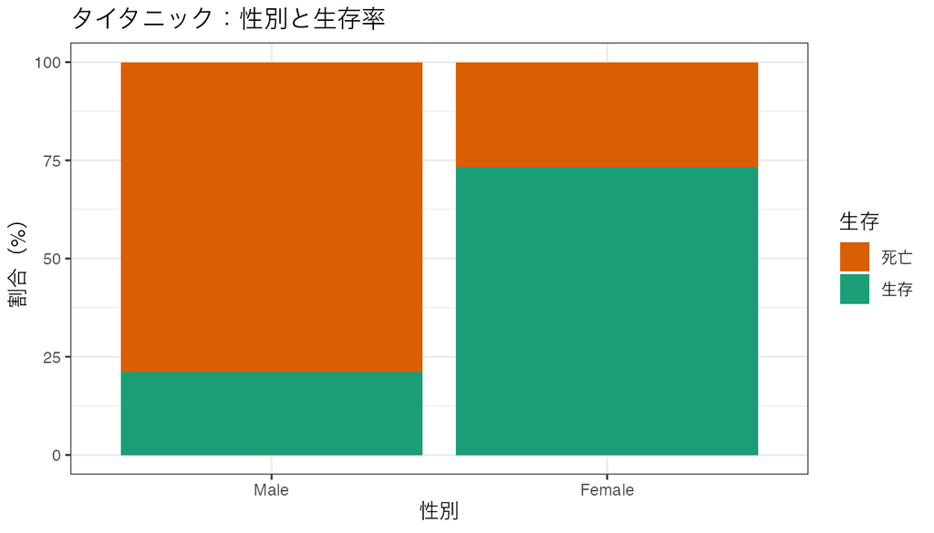

```r
titanic_pct <- titanic_summary |>
  group_by(Sex) |>
  mutate(pct = Freq / sum(Freq) * 100)

ggplot(titanic_pct, aes(x = Sex, y = pct, fill = Survived)) +
  geom_col() +
  scale_fill_manual(values = c("No" = "#D95F02", "Yes" = "#1B9E77"),
                    labels = c("No" = "死亡", "Yes" = "生存")) +
  labs(title = "タイタニック：性別と生存率",
       x = "性別", y = "割合（%）", fill = "生存") +
  theme_bw()
```

## 7. 結果の報告

論文・レポートでの記述例：

> 性別と生存の独立性を検定するためにカイ二乗検定を実施した。 その結果，性別と生存の間には有意な関連が認められた， χ²(1, N = 2201) = 454.5, p < .001, *V* = .46。

> $\chi^2$ と $p$ は `chisq.test()` の既定（イェーツ補正あり）の値， $V$ は補正を外して計算した値です。検定と効果量で目的が違うためで，食い違いではありません。

## 演習

### 演習1：クロス集計表の作成

`mtcars` データを使って，シリンダー数（`cyl`）とトランスミッション（`am`）の クロス集計表を作成してください。

```r
table(mtcars$cyl, mtcars$am)
```

### 演習2：カイ二乗検定

演習1のクロス集計表を使って，カイ二乗検定を実施し，結果を解釈してください。

- 仮説を日本語で書く
- `chisq.test()` を実行する
- **期待度数を確認する**
- p値と自由度を確認し，結論を書く

```r
tab <- table(mtcars$cyl, mtcars$am)
chisq.test(tab)
chisq.test(tab)$expected
```

### ⚠ この表では警告が出ます

> 実行すると **「カイ自乗近似は不正確かもしれません」**という警告が出ます。 期待度数を見ると，6セルのうち**3セル（50%）が5未満**です。 4節の目安「5未満のセルが全体の20%を超えないこと」を満たしていません。

> **警告が出たまま報告してはいけません。** フィッシャーの正確確率検定に切り替えてください。

> ```r
> fisher.test(tab)
> ```

> この例では，カイ二乗検定が $p$ = .013，フィッシャーが $p$ = .009 で， **どちらも有意という結論は変わりません。** 結論が変わらないことを確かめたうえで，**フィッシャーの結果を報告します。**

### 演習3：可視化

`mtcars` の `cyl`（シリンダー数）と `am`（0=オートマ, 1=マニュアル）の 関係を積み上げ棒グラフで表現してください。

```r
mtcars |>
  mutate(
    am  = factor(am,  labels = c("オートマ", "マニュアル")),
    cyl = factor(cyl, labels = c("4気筒", "6気筒", "8気筒"))
  ) |>
  group_by(cyl, am) |>
  summarise(n = n(), .groups = "drop") |>
  group_by(cyl) |>
  mutate(pct = n / sum(n) * 100) |>
  ggplot(aes(x = cyl, y = pct, fill = am)) +
  geom_col() +
  labs(title = "シリンダー数とトランスミッションの関係",
       x = "シリンダー数", y = "割合（%）", fill = "トランスミッション") +
  theme_bw()
```

## 本日のまとめ

- カテゴリデータの分析には**クロス集計表とカイ二乗検定**を使う
- `table()` / `xtabs()` でクロス集計表を作成
- `chisq.test()` で独立性を検定
- **期待度数が5未満のセルがあれば `fisher.test()` に切り替える**
- 3×2以上の表では**調整済み残差**を見て，どのセルが効いているかを読む
- 効果量（クラメールの V）も一緒に報告する
- 積み上げ棒グラフでカテゴリ間の比率を可視化する

## 宿題・予習

- 演習2の結果をレポート形式でまとめる（1〜2文）
- 次回は **t検定（2群の平均値の比較）** を学びます
- 教科書のt検定に関する章を読んでおく